# Changing established atttiudes via the IAT: Experiment 3

Ian Hussey

```r
# dependencies
library(tidyverse)
library(psych)
library(weights)  # for rd(), a round() alternative
library(plotrix)  # for std.error
library(lme4)
library(effects)
library(knitr)
library(kableExtra)
library(sjPlot)
library(kableExtra)
library(apa)

# rounds all numerics in a df
round_df <- function(df, digits) {
  nums <- vapply(df, is.numeric, FUN.VALUE = logical(1))
  df[,nums] <- round(df[,nums], digits = digits)
  (df)
}

# options
options(knitr.table.format = "html") # necessary configuration of tables

# disable scientific notation
options(scipen = 999)
```

# Descriptive statistics

## Full sample

```r
# get data
data_df <-
  read.csv("data/processed/processed summary data - wide format.csv") %>%
  dplyr::mutate(gender = as.factor(gender))

#colnames(data_df)

attrition_rate <- data_df %>%
  dplyr::summarize(rate = round(sum(exclude)/n()*100, 1)) %>%
  as.numeric()

data_df %>%
  count(exclude) %>%
  kable() %>%
  kable_styling(bootstrap_options = c("striped", "hover", "condensed"), full_width = FALSE)
```

| exclude | n |
| --- | --- |
| FALSE | 246 |
| TRUE | 48 |

```r
data_df %>%
  count(exclude, IAT_condition) %>%
  kable() %>%
  kable_styling(bootstrap_options = c("striped", "hover", "condensed"), full_width = FALSE)
```

| exclude | IAT_condition | n |
| --- | --- | --- |
| FALSE | Flowers-Insects IAT | 116 |
| FALSE | Race IAT | 130 |
| TRUE | Flowers-Insects IAT | 31 |
| TRUE | Race IAT | 17 |

```r
chi2_result <- data_df %>%
  count(IAT_condition, exclude) %>%
  spread(exclude, n) %>%
  select(-IAT_condition) %>%
  chisq.test(.) %>%
  chisq_apa(., print_n = TRUE, format = c("rmarkdown"), info = FALSE, print = FALSE)
```

Attrition rate = 16.3%.

A chi squared test was used to assess whether the conditions suffered from differential attrition rates: $\chi^2$(1, n = 294) = 4.21, *p* = .040. [nb results of p = 1.0 will show as = .000 due to an error in how chisq_apa trims its results]

## Analytic sample

I.e., after applying inclusion/exclusion criteria.

### Age

```r
passers_df <- data_df %>%
  filter(exclude == FALSE)

passers_df %>%
  dplyr::select(age) %>%
  psych::describe(fast = TRUE,  # subset of descriptive stats
                  ranges = FALSE,
                  trim = 0) %>%
  dplyr::select(-vars, -se) %>%
  kable() %>%
  kable_styling(bootstrap_options = c("striped", "hover", "condensed"), full_width = FALSE)
```

|  | n | mean | sd |
| --- | --- | --- | --- |
| age | 245 | 36.14286 | 11.51051 |

### Gender

```r
passers_df %>%
  dplyr::count(gender) %>%
  kable() %>%
  kable_styling(bootstrap_options = c("striped", "hover", "condensed"), full_width = FALSE)
```

| gender | n |
| --- | --- |
| 31 | 1 |
| 53 | 1 |
| female | 148 |
| female | 4 |
| male | 90 |
| male | 1 |
| non-binary | 1 |

### Performance on the IAT and shooter task

```r
passers_df %>%
  dplyr::select(IAT_mean_RT,
                IAT_perc_acc,
                shooter_mean_RT,
                shooter_perc_acc) %>%
  psych::describe(fast = TRUE,  # subset of descriptive stats
                  ranges = FALSE,
                  trim = 0) %>%
  dplyr::select(-vars, -se) %>%
  mutate(mean = round(mean, 2),
         sd = round(sd, 2)) %>%
  kable() %>%
  kable_styling(bootstrap_options = c("striped", "hover", "condensed"), full_width = FALSE)
```

| n | mean | sd |
| --- | --- | --- |
| 246 | 894.17 | 222.16 |
| 246 | 0.94 | 0.05 |
| 245 | 625.99 | 56.61 |
| 245 | 0.89 | 0.09 |

# Hypothesis test 1: Differences in Shooter task RT effects between IAT conditions

H1-H3: Completing an IAT serves to train attitudes as well as test them. Participants who complete a race IAT will influence implicit biases towards black people on the on the shooter task relative to participants who completed a control (flowers-insects) IAT.

H1 refers to the RT analysis: interaction effect between condition and trial type. Preregistered code mistakenly referred to the main effect too, but a difference in responding speed between conditions does not represent a racial bias.

## Outlier removal

Exclude data points > 2.5 SD from mean.

```r
# exclude participants who had more than 10% of trials in less than 300ms, and make variables factors
shooter_data <-
  read.csv("data/processed/processed shooter task data - long format.csv") %>%
  dplyr::mutate(participant = as.factor(participant),
                trial_type = as.factor(trial_type),
                IAT_condition = as.factor(IAT_condition)) %>%
  filter(IAT_exclude_based_on_fast_trials == FALSE)

# exclude outlier rts
shooter_data_outliers_removed <- shooter_data %>%
  schoRsch::outlier(dv = "rt",
                    todo="elim",
                    upper.z = 2.5,
                    lower.z = -2.5)
```

```
## [1] "Function outlier() has screened 18126 trial(s) in total. Of these were 198 trial(s) identified as outliers (1.09%)."
```

### Plot distribution

Distribution of shooter RTs after trimming outliers.

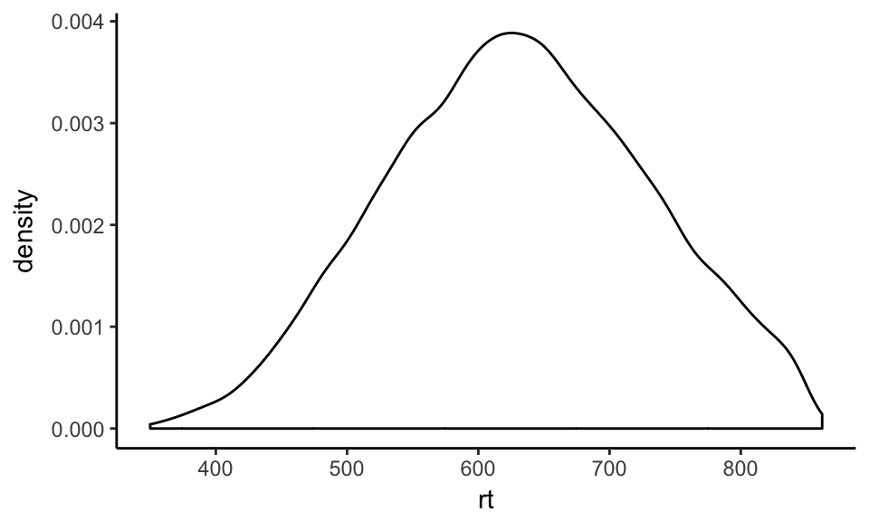

```r
ggplot(data = shooter_data_outliers_removed) +
  geom_density(aes(x = rt)) +
  theme_classic()
```

## Linear mixed model

### Model

```r
model_1 <- lmer(rt ~ trial_type * IAT_condition + modern_racism_scale_total + (1 | participant),
                contrasts = list(trial_type = "contr.sum", IAT_condition = "contr.sum"),
                data = shooter_data_outliers_removed)
```

- Hypothesis refers to the main effect for IAT condition or the IAT condition*trial type interaction effect.
- Confidence intervals via Wald estimation.

### Summary

```r
sjt.lmer(model_1,
         emph.p = FALSE,
         p.kr = FALSE,
         show.std = TRUE,
         digits.est = 3,
         digits.ci = 3)
```

|  |  | B | CI | std. Beta | CI | p |
| --- | --- | --- | --- | --- | --- | --- |
| Fixed Parts |  |  |  |  |  |  |
| (Intercept) |  | 633.156 | 609.601 – 656.711 |  |  | <.001 |
| trial_type1 |  | -28.853 | -30.134 – -27.572 | -0.291 | -0.304 – -0.278 | <.001 |
| IAT_condition1 |  | -6.000 | -10.925 – -1.075 | -0.060 | -0.110 – -0.011 | .017 |
| modern_racism_scale_total |  | -0.086 | -1.446 – 1.273 | -0.003 | -0.052 – 0.046 | .901 |
| trial_type1:IAT_condition1 |  | 0.983 | -0.298 – 2.264 | 0.010 | -0.003 – 0.023 | .133 |
| Random Parts |  |  |  |  |  |  |
| σ<sup>2</sup> |  | 7633.667 |  |  |  |  |
| τ<sub>00, participant</sub> |  | 1427.919 |  |  |  |  |
| N<sub>participant</sub> |  | 245 |  |  |  |  |
| ICC<sub>participant</sub> |  | 0.158 |  |  |  |  |
| Observations |  | 17928 |  |  |  |  |
| R<sup>2</sup> / Ω<sub>0</sub><sup>2</sup> |  | .234 / .234 |  |  |  |  |

### Plot effects

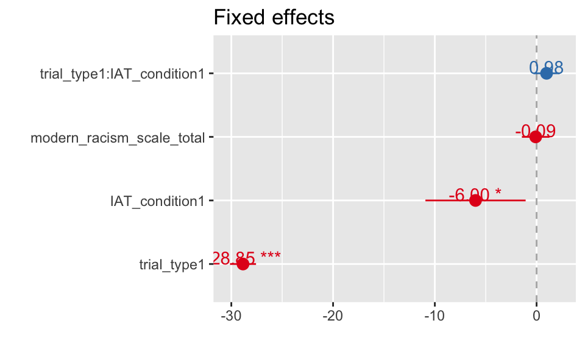

```r
sjp.lmer(model_1,
         p.kr = FALSE,
         type = "fe")
```

### Table predictions

```r
model_1_predicted_effects <-
  as.data.frame(effect("trial_type:IAT_condition", model_1)) %>%
  dplyr::rename(`IAT condition` = IAT_condition,
         `Trial type` = trial_type)

model_1_predicted_effects %>%
  round_df(2) %>%
  kable() %>%
  kable_styling(bootstrap_options = c("striped", "hover", "condensed"), full_width = FALSE)
```

| Trial type | IAT condition | fit | se | lower | upper |
| --- | --- | --- | --- | --- | --- |
| gun | Flowers-Insects IAT | 597.82 | 3.77 | 590.44 | 605.21 |
| object | Flowers-Insects IAT | 653.57 | 3.77 | 646.17 | 660.96 |
| gun | Race IAT | 607.86 | 3.56 | 600.88 | 614.84 |
| object | Race IAT | 667.53 | 3.57 | 660.53 | 674.53 |

### Plot predictions

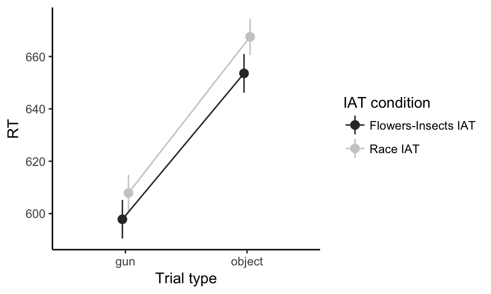

```r
ggplot(data = model_1_predicted_effects,
       aes(x = `Trial type`, y = fit, colour = `IAT condition`)) +
  geom_pointrange(aes(ymax = upper,
                      ymin = lower),
                  position = position_dodge(width = .1)) +
  geom_line(aes(group = `IAT condition`),
            position = position_dodge(width = .1)) +
  ylab("RT") +
  xlab("Trial type") +
  scale_colour_grey() +
  theme_classic()
```

```r
  # theme(legend.justification=c(0.5,1), legend.position=c(0.5,1),
  #       legend.key = element_rect(colour = "transparent"))
```

# Hypothesis test 2: differences in Shooter task sensitivity (d’) between IAT conditions

H2 refers to the sensitivity analysis: main effect for IAT condition.

## Model

```r
model_2 <- lm(d ~ IAT_condition + modern_racism_scale_total,
              contrasts = list(IAT_condition = "contr.sum"),
              data = passers_df)
```

## Summary

```r
sjt.lm(model_2,
       emph.p = FALSE,
       show.std = TRUE,
       digits.est = 2,
       digits.ci = 2)
```

|  |  | B | CI | std. Beta | CI | p |
| --- | --- | --- | --- | --- | --- | --- |
| (Intercept) |  | 2.65 | 2.09 – 3.22 |  |  | <.001 |
| IAT_condition (Race IAT) |  | 0.02 | -0.10 – 0.14 | 0.02 | -0.10 – 0.15 | .741 |
| modern_racism_scale_total |  | 0.00 | -0.03 – 0.04 | 0.01 | -0.11 – 0.14 | .823 |
| Observations |  | 245 |  |  |  |  |
| R<sup>2</sup> / adj. R<sup>2</sup> |  | .001 / -.008 |  |  |  |  |

## Plot effects

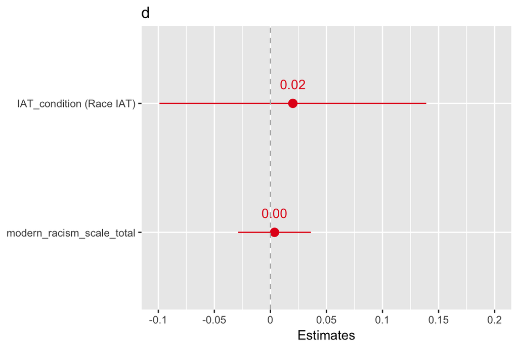

```r
sjp.lm(model_2,
       type = "fe")
```

# Hypothesis test 3: differences in Shooter task response bias (c) between conditions

H3 refers to the response bias analysis: main effect for IAT condition.

## Model

```r
model_3 <- lm(c ~ IAT_condition + modern_racism_scale_total,
              contrasts = list(IAT_condition = "contr.sum"),
              data = passers_df)
```

## Summary

```r
sjt.lm(model_3,
       emph.p = FALSE,
       show.std = TRUE,
       digits.est = 3,
       digits.ci = 3)
```

|  |  | B | CI | std. Beta | CI | p |
| --- | --- | --- | --- | --- | --- | --- |
| (Intercept) |  | 0.069 | -0.109 – 0.247 |  |  | .446 |
| IAT_condition (Race IAT) |  | 0.004 | -0.034 – 0.042 | 0.013 | -0.113 – 0.139 | .840 |
| modern_racism_scale_total |  | -0.002 | -0.012 – 0.008 | -0.027 | -0.153 – 0.099 | .673 |
| Observations |  | 245 |  |  |  |  |
| R<sup>2</sup> / adj. R<sup>2</sup> |  | .001 / -.007 |  |  |  |  |

## Plot effects

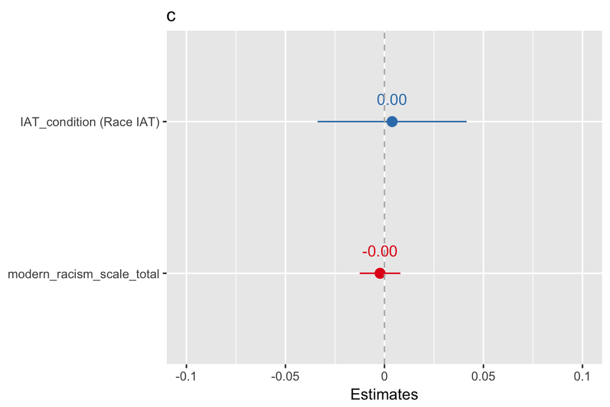

```r
sjp.lm(model_3,
       type = "fe")
```

# Hypothesis test 4: Differences in self-reported ratings between IAT conditions

H4: Participants who complete a race IAT will demonstrate more negative self-reported evaluations of the outgroup (black people) on the ratings than participants who completed a control (flowers-insects) IAT.

```r
ratings_data <-
  read.csv("data/processed/processed ratings data - long format.csv") %>%
  dplyr::mutate(participant = as.factor(participant)) %>%
  mutate(IAT_condition = fct_relevel(as.factor(IAT_condition), "Race IAT", "Flowers-Insects IAT")) %>%
  filter(IAT_exclude_based_on_fast_trials == FALSE)
```

## Linear mixed model

### Model

```r
model_4 <- lmer(rating ~ IAT_condition + modern_racism_scale_total + (1 | participant),
                contrasts = list(IAT_condition = "contr.sum"),
                data = ratings_data)
```

### Summary

```r
sjt.lmer(model_4,
         emph.p = FALSE,
         p.kr = FALSE,
         show.std = TRUE)
```

|  |  | B | CI | std. Beta | CI | p |
| --- | --- | --- | --- | --- | --- | --- |
| Fixed Parts |  |  |  |  |  |  |
| (Intercept) |  | 5.01 | 4.48 – 5.54 |  |  | <.001 |
| IAT_condition (Flowers-Insects IAT) |  | 0.19 | 0.08 – 0.31 | 0.18 | 0.08 – 0.28 | <.001 |
| modern_racism_scale_total |  | -0.03 | -0.06 – -0.00 | -0.11 | -0.22 – -0.01 | .034 |
| Random Parts |  |  |  |  |  |  |
| σ<sup>2</sup> |  | 0.371 |  |  |  |  |
| τ<sub>00, participant</sub> |  | 0.737 |  |  |  |  |
| N<sub>participant</sub> |  | 246 |  |  |  |  |
| ICC<sub>participant</sub> |  | 0.665 |  |  |  |  |
| Observations |  | 1476 |  |  |  |  |
| R<sup>2</sup> / Ω<sub>0</sub><sup>2</sup> |  | .731 / .728 |  |  |  |  |

### Plot effects

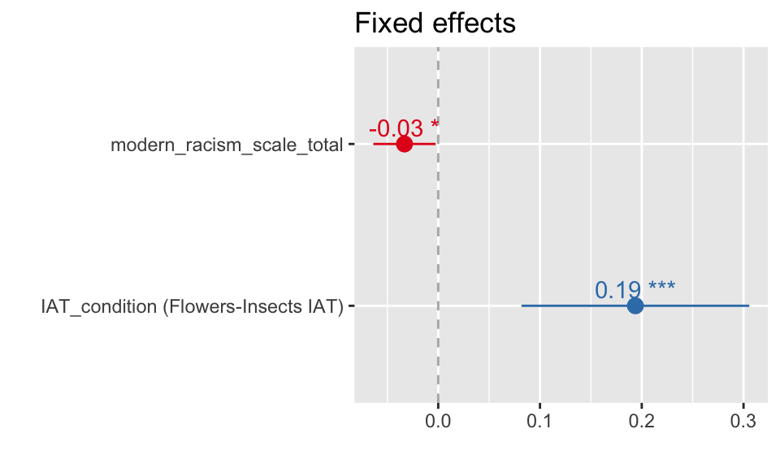

```r
sjp.lmer(model_4,
         p.kr = FALSE,
         type = "fe")
```

### Table predictions

```r
model_4_predicted_effects <- as.data.frame(effect("IAT_condition", model_4))

model_4_predicted_effects %>%
  round_df(2) %>%
  kable() %>%
  kable_styling(bootstrap_options = c("striped", "hover", "condensed"), full_width = FALSE)
```

| IAT_condition | fit | se | lower | upper |
| --- | --- | --- | --- | --- |
| Race IAT | 4.64 | 0.08 | 4.49 | 4.79 |
| Flowers-Insects IAT | 4.25 | 0.08 | 4.09 | 4.42 |

### Plot predictions

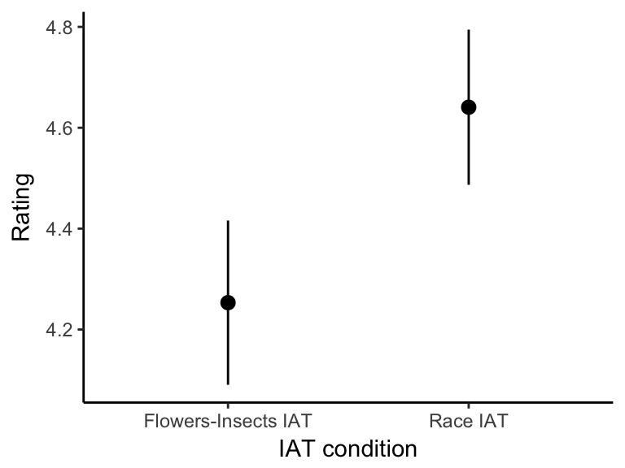

```r
ggplot(data = model_4_predicted_effects,
       aes(x = IAT_condition, y = fit)) +
  geom_pointrange(aes(ymax = upper,
                      ymin = lower)) +
  ylab("Rating") +
  xlab("IAT condition") +
  scale_colour_grey() +
  theme_classic()
```